# Red Wine Data Exploration by Christian Guzman

> This report explores a data set containing quality rating and other attributes for approximately 1,600 red wines.

# Univariate Plots Section

```
## [[1]]
##        X          fixed.acidity   volatile.acidity  citric.acid
##  Min.   :   1.0   Min.   : 4.60   Min.   :0.1200   Min.   :0.000
##  1st Qu.: 400.5   1st Qu.: 7.10   1st Qu.:0.3900   1st Qu.:0.090
##  Median : 800.0   Median : 7.90   Median :0.5200   Median :0.260
##  Mean   : 800.0   Mean   : 8.32   Mean   :0.5278   Mean   :0.271
##  3rd Qu.:1199.5   3rd Qu.: 9.20   3rd Qu.:0.6400   3rd Qu.:0.420
##  Max.   :1599.0   Max.   :15.90   Max.   :1.5800   Max.   :1.000
##  residual.sugar     chlorides       free.sulfur.dioxide
##  Min.   : 0.900   Min.   :0.01200   Min.   : 1.00
##  1st Qu.: 1.900   1st Qu.:0.07000   1st Qu.: 7.00
##  Median : 2.200   Median :0.07900   Median :14.00
##  Mean   : 2.539   Mean   :0.08747   Mean   :15.87
##  3rd Qu.: 2.600   3rd Qu.:0.09000   3rd Qu.:21.00
##  Max.   :15.500   Max.   :0.61100   Max.   :72.00
##  total.sulfur.dioxide    density             pH          sulphates
##  Min.   :  6.00       Min.   :0.9901   Min.   :2.740   Min.   :0.3300
##  1st Qu.: 22.00       1st Qu.:0.9956   1st Qu.:3.210   1st Qu.:0.5500
##  Median : 38.00       Median :0.9968   Median :3.310   Median :0.6200
##  Mean   : 46.47       Mean   :0.9967   Mean   :3.311   Mean   :0.6581
##  3rd Qu.: 62.00       3rd Qu.:0.9978   3rd Qu.:3.400   3rd Qu.:0.7300
##  Max.   :289.00       Max.   :1.0037   Max.   :4.010   Max.   :2.0000
##     alcohol         quality
##  Min.   : 8.40   Min.   :3.000
##  1st Qu.: 9.50   1st Qu.:5.000
##  Median :10.20   Median :6.000
##  Mean   :10.42   Mean   :5.636
##  3rd Qu.:11.10   3rd Qu.:6.000
##  Max.   :14.90   Max.   :8.000
##
## [[2]]
##  [1] "X"                    "fixed.acidity"        "volatile.acidity"
##  [4] "citric.acid"          "residual.sugar"       "chlorides"
##  [7] "free.sulfur.dioxide"  "total.sulfur.dioxide" "density"
## [10] "pH"                   "sulphates"            "alcohol"
## [13] "quality"
```

```
## 'data.frame':    1599 obs. of  13 variables:
##  $ X                   : int  1 2 3 4 5 6 7 8 9 10 ...
##  $ fixed.acidity       : num  7.4 7.8 7.8 11.2 7.4 7.4 7.9 7.3 7.8 7.5 ...
##  $ volatile.acidity    : num  0.7 0.88 0.76 0.28 0.7 0.66 0.6 0.65 0.58 0.5 ...
##  $ citric.acid         : num  0 0 0.04 0.56 0 0 0.06 0 0.02 0.36 ...
##  $ residual.sugar      : num  1.9 2.6 2.3 1.9 1.9 1.8 1.6 1.2 2 6.1 ...
##  $ chlorides           : num  0.076 0.098 0.092 0.075 0.076 0.075 0.069 0.065 0.073 0.071 ...
##  $ free.sulfur.dioxide : num  11 25 15 17 11 13 15 15 9 17 ...
##  $ total.sulfur.dioxide: num  34 67 54 60 34 40 59 21 18 102 ...
##  $ density             : num  0.998 0.997 0.997 0.998 0.998 ...
##  $ pH                  : num  3.51 3.2 3.26 3.16 3.51 3.51 3.3 3.39 3.36 3.35 ...
##  $ sulphates           : num  0.56 0.68 0.65 0.58 0.56 0.56 0.46 0.47 0.57 0.8 ...
##  $ alcohol             : num  9.4 9.8 9.8 9.8 9.4 9.4 9.4 10 9.5 10.5 ...
##  $ quality             : int  5 5 5 6 5 5 5 7 7 5 ...
## NULL
```

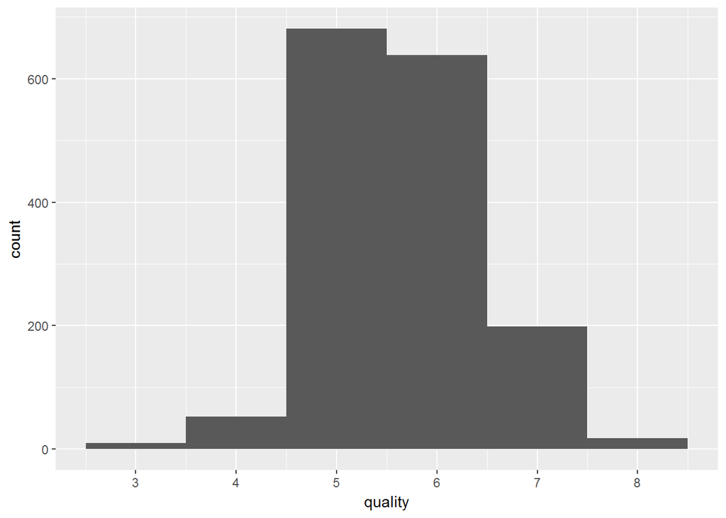

```
##    Min. 1st Qu.  Median    Mean 3rd Qu.    Max.
##   3.000   5.000   6.000   5.636   6.000   8.000
```

```
##
##   3   4   5   6   7   8
##  10  53 681 638 199  18
```

The first plot is a histogram showing the distribution of the quality.

Since there are few wines rated below 5, and above 7 the data will barely be noticeable. As such I will combine the quality ratings.

```
##    Poor    Good Premium
##     744     638     217
```

Wines rated from 3 to 5, 6, and 7 to 8 will be labeled as “Poor”, “Good”, and “Premium” respectively.

```
## [1] "integer"
```

```
##  Factor w/ 3 levels "Poor","Good",..: 1 1 1 2 1 1 1 3 3 1 ...
```

The new feature “rating” is a factor of 3 levels. We can use this new feature to analyze the data in new ways.

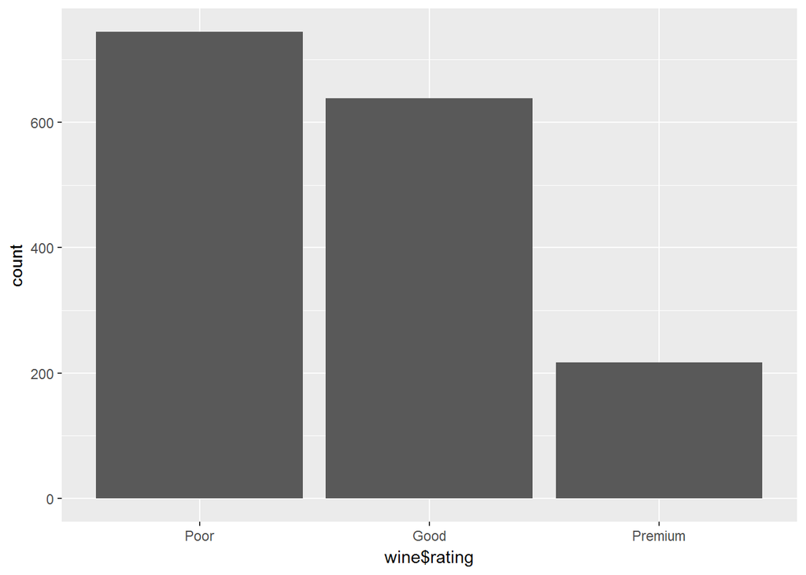

The bar graph shows each level with a significant amount of wines. Premium happens to have significantly fewer data that Poor and Good wines.

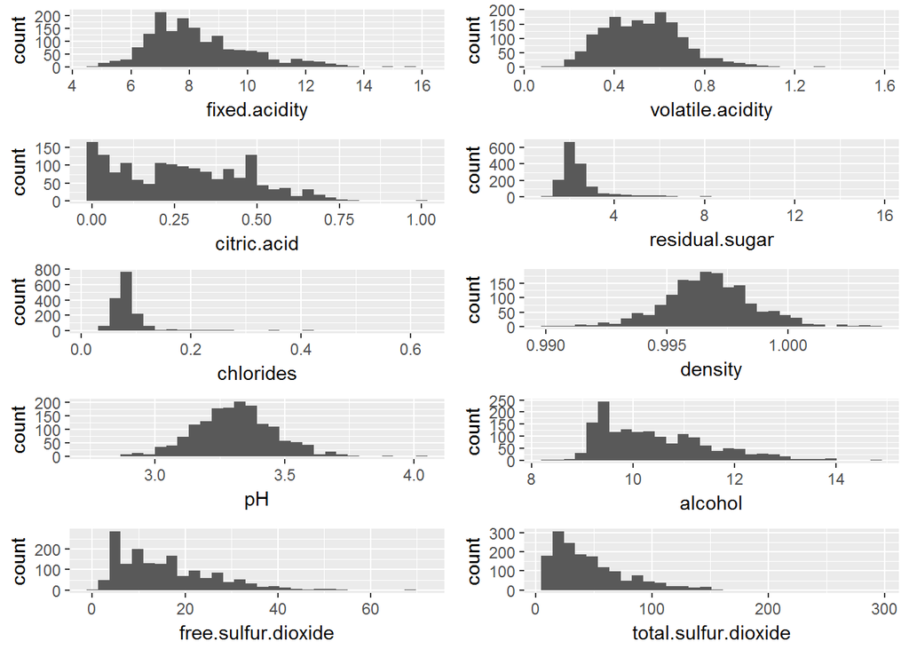

I would describe the majority of the plots to be skewed. Specifically, all variables except for “pH” and “density” have obvious right skew. With “residual.sugar”, “chlorides” free and total sulf dioxide as having strong right skew, and long right tails.

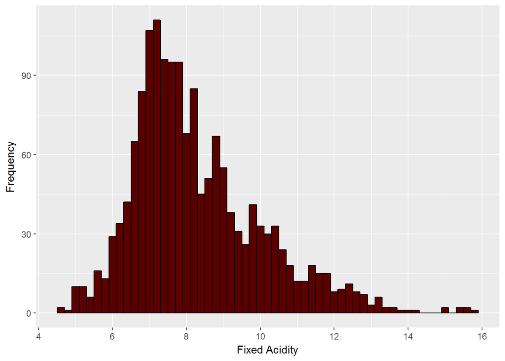

Fixed acidity (Tartaric acid): We can see that most wines have fixed acidity value between 6 and 9 g/L.

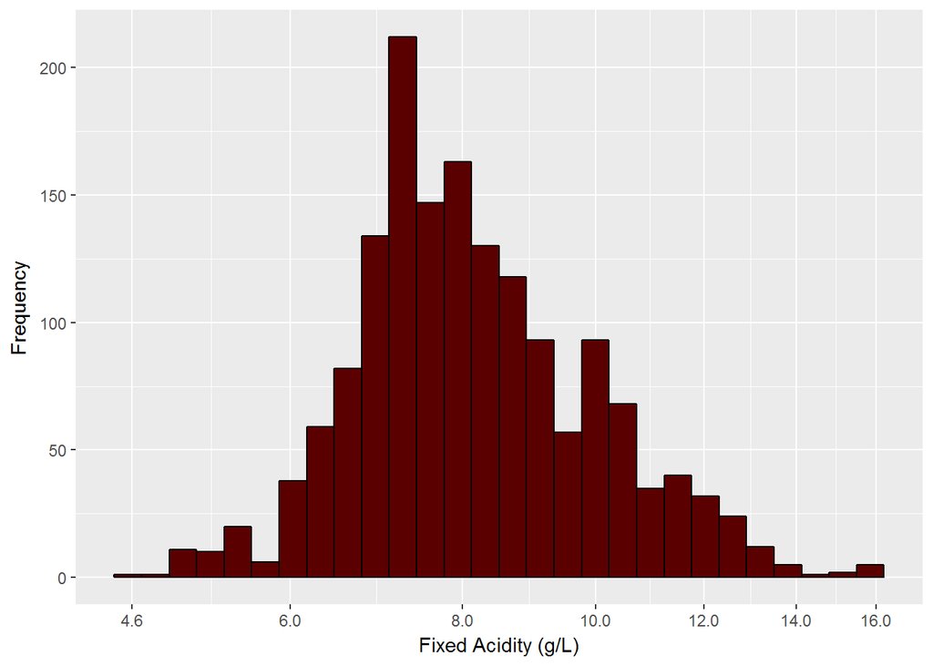

```
## wine$rating: Poor
##    Min. 1st Qu.  Median    Mean 3rd Qu.    Max.
##   4.600   7.100   7.800   8.142   8.900  15.900
## --------------------------------------------------------
## wine$rating: Good
##    Min. 1st Qu.  Median    Mean 3rd Qu.    Max.
##   4.700   7.000   7.900   8.347   9.400  14.300
## --------------------------------------------------------
## wine$rating: Premium
##    Min. 1st Qu.  Median    Mean 3rd Qu.    Max.
##   4.900   7.400   8.700   8.847  10.100  15.600
```

The above histogram shows the log transformation of the “fixed.acidity” variable. The log transformation can help view the data with much less skew and with usually less extreme outliers. The log transform will be applied to most of the data.

Dubbed the most important process in winemaking, I hope to discover its relationship to other features and wine quality.

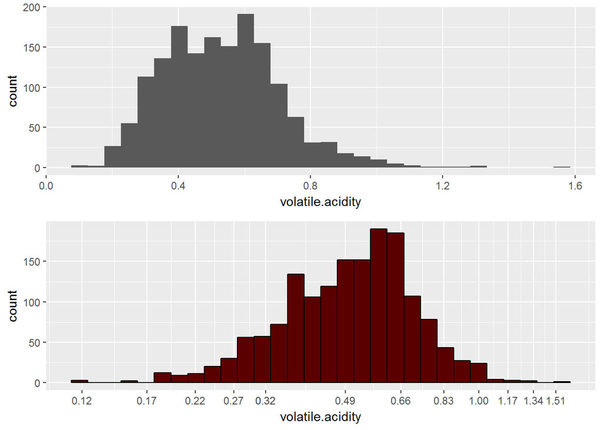

```
##    Min. 1st Qu.  Median    Mean 3rd Qu.    Max.
##  0.1200  0.3900  0.5200  0.5278  0.6400  1.5800
```

```
## wine$rating: Poor
##    Min. 1st Qu.  Median    Mean 3rd Qu.    Max.
##  0.1800  0.4600  0.5900  0.5895  0.6800  1.5800
## --------------------------------------------------------
## wine$rating: Good
##    Min. 1st Qu.  Median    Mean 3rd Qu.    Max.
##  0.1600  0.3800  0.4900  0.4975  0.6000  1.0400
## --------------------------------------------------------
## wine$rating: Premium
##    Min. 1st Qu.  Median    Mean 3rd Qu.    Max.
##  0.1200  0.3000  0.3700  0.4055  0.4900  0.9150
```

Volatile acidity (acetic acid): The transformed distribution is unimodal, and peaks near between .49 and 0.66 g/L. I would imagine this feature being an important variable for quality since too high a level can give the wine an unpleasant vinegar taste.

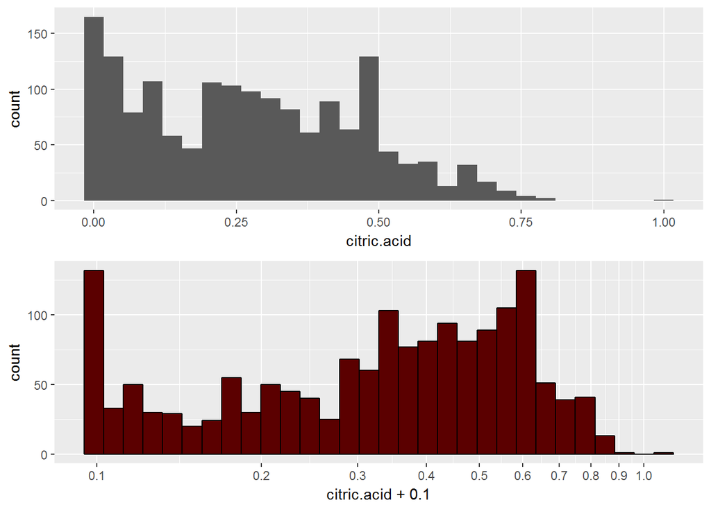

```
##    Min. 1st Qu.  Median    Mean 3rd Qu.    Max.
##   0.000   0.090   0.260   0.271   0.420   1.000
```

```
## wine$rating: Poor
##    Min. 1st Qu.  Median    Mean 3rd Qu.    Max.
##  0.0000  0.0800  0.2200  0.2378  0.3600  1.0000
## --------------------------------------------------------
## wine$rating: Good
##    Min. 1st Qu.  Median    Mean 3rd Qu.    Max.
##  0.0000  0.0900  0.2600  0.2738  0.4300  0.7800
## --------------------------------------------------------
## wine$rating: Premium
##    Min. 1st Qu.  Median    Mean 3rd Qu.    Max.
##  0.0000  0.3000  0.4000  0.3765  0.4900  0.7600
```

Citric acid: The distribution has a right skew, and the transformed  
distribution appears bimodal with a peak being near 0.6 and the other peak near 0.1. Many of the values are clustered near 0.

Another observation to note is that higher quality wines have a higher mean and median for citric acid. This could imply that citric acid is an import factor in wine quality especially since it gives wine its freshness.

```
##    Min. 1st Qu.  Median    Mean 3rd Qu.    Max.
##   0.900   1.900   2.200   2.539   2.600  15.500
```

```
##    Min. 1st Qu.  Median    Mean 3rd Qu.    Max.
##  0.0000  0.3010  0.3617  0.3884  0.4314  1.1931
```

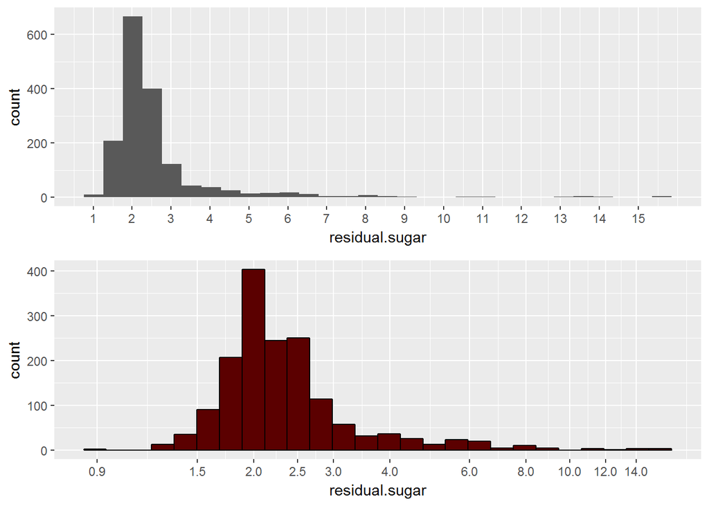

For the dataset we can see that most of the wines have between 1.5 and 3.0 grams per liter of residual sugar.

```
##    Min. 1st Qu.  Median    Mean 3rd Qu.    Max.
##   0.900   1.900   2.200   2.539   2.600  15.500
```

```
## wine$rating: Poor
##    Min. 1st Qu.  Median    Mean 3rd Qu.    Max.
##   1.200   1.900   2.200   2.542   2.600  15.500
## --------------------------------------------------------
## wine$rating: Good
##    Min. 1st Qu.  Median    Mean 3rd Qu.    Max.
##   0.900   1.900   2.200   2.477   2.500  15.400
## --------------------------------------------------------
## wine$rating: Premium
##    Min. 1st Qu.  Median    Mean 3rd Qu.    Max.
##   1.200   2.000   2.300   2.709   2.700   8.900
```

As can be seen by the summary of residual sugar content by wine rating, there is no clear trend. Could it be that residual sugar is not an important feature? The lower rated wines do have a higher max value but similar medians, and premium wines have a higher mean of residual sugar content.

```
##    Min. 1st Qu.  Median    Mean 3rd Qu.    Max.
##  -1.921  -1.155  -1.102  -1.088  -1.046  -0.214
```

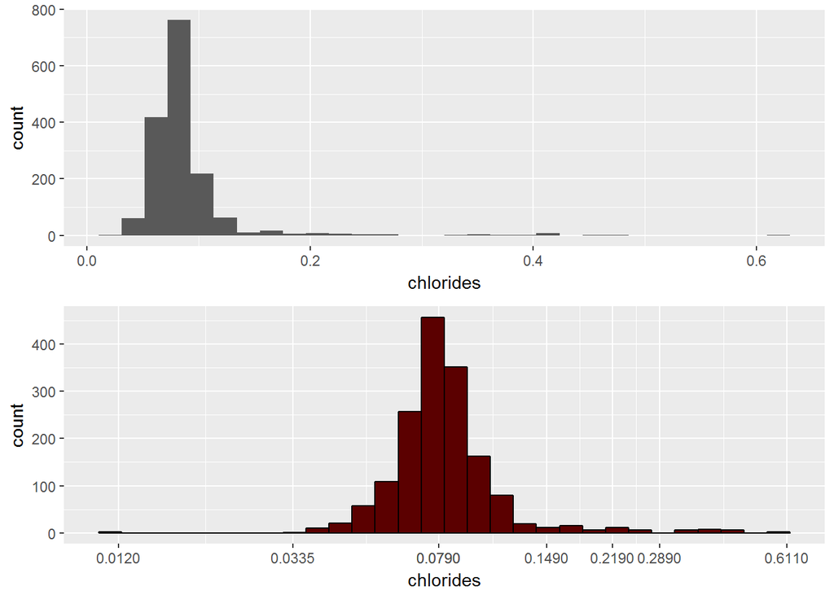

The chlorides variable is the other strongly right skewed variable. With a log transformation we can get a better sense of the structure of the data.

The distribution is unimodal with the median being 0.0790 grams/liter of salt content in the wines. Most values are between .0335 and .1490.

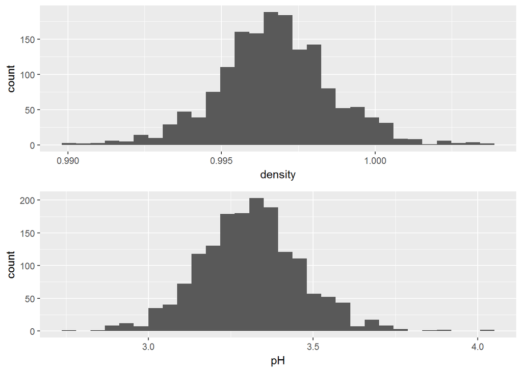

```
##    Min. 1st Qu.  Median    Mean 3rd Qu.    Max.
##  0.9901  0.9956  0.9968  0.9967  0.9978  1.0037
```

The distributions for density and pH resemble a normal distribution.

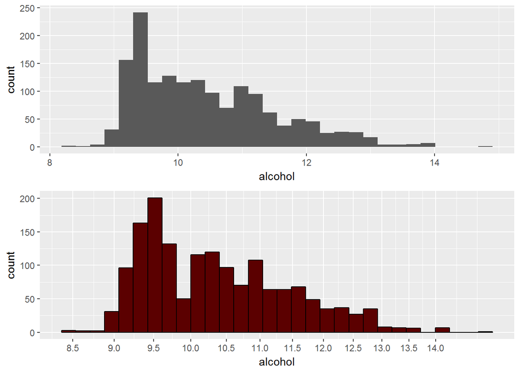

```
##    Min. 1st Qu.  Median    Mean 3rd Qu.    Max.
##    8.40    9.50   10.20   10.42   11.10   14.90
```

```
##
##   8   9  10  11  12  13  14  15
##   3 294 686 336 210  56  13   1
```

As can be seen a log transformation hardly transforms the distribution. We can see More clearly however that alcohol content peaks at 9.5.

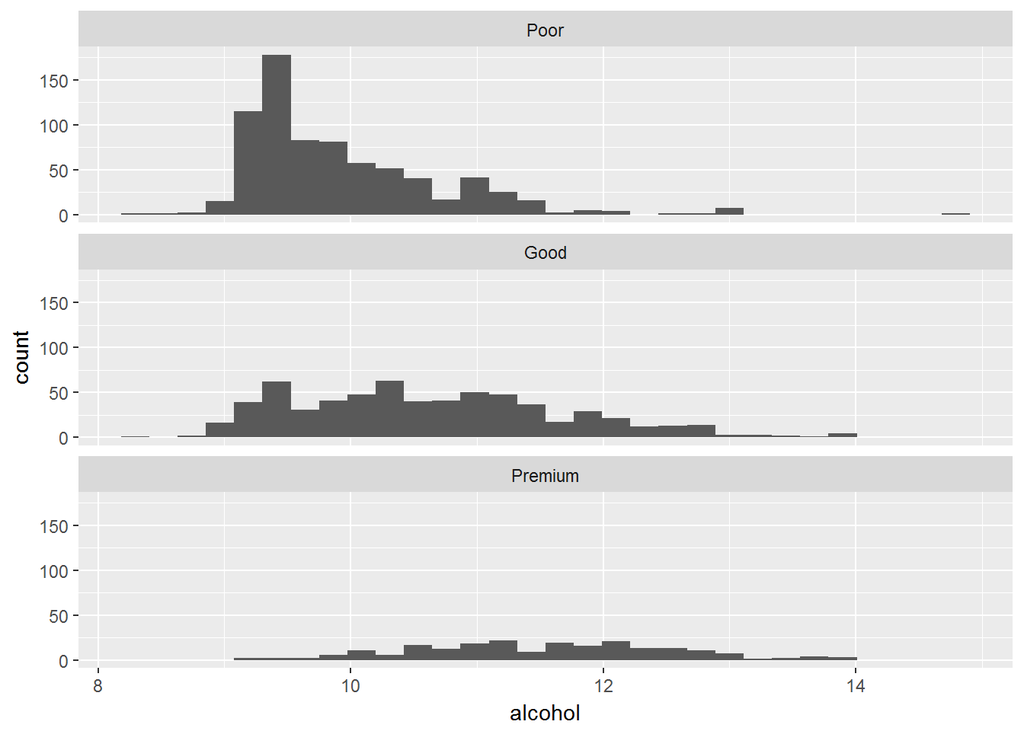

Plotting the distribution of alcohol faceting on wine quality rating variable, a trend can be seen that there are far less higher rated wines with lower alcohol content and the poor rated wines peak at 9.5. The distributions shift to the right.

```
## wine$rating: Poor
##    Min. 1st Qu.  Median    Mean 3rd Qu.    Max.
##   8.400   9.400   9.700   9.926  10.300  14.900
## --------------------------------------------------------
## wine$rating: Good
##    Min. 1st Qu.  Median    Mean 3rd Qu.    Max.
##    8.40    9.80   10.50   10.63   11.30   14.00
## --------------------------------------------------------
## wine$rating: Premium
##    Min. 1st Qu.  Median    Mean 3rd Qu.    Max.
##    9.20   10.80   11.60   11.52   12.20   14.00
```

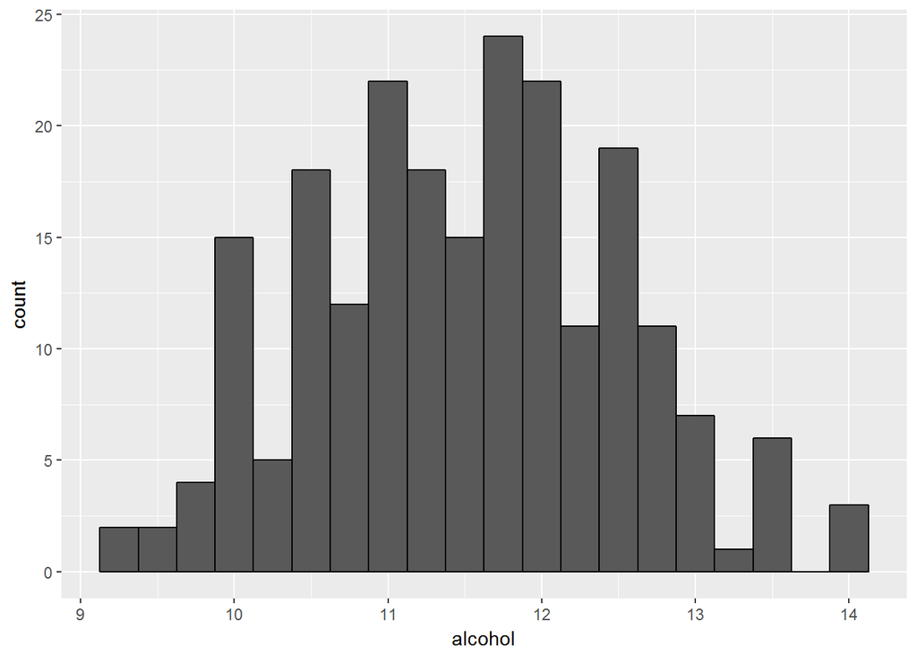

```
##    Min. 1st Qu.  Median    Mean 3rd Qu.    Max.
##    9.20   10.80   11.60   11.52   12.20   14.00
```

From the above the premium wines group have a median of 11.60 and good and poor wine groups have medians 10.50 and 9.70 respectively indicating a trend that higher rated wines are more likely to have higher alcohol content.

```r
qplot(x = free.sulfur.dioxide / total.sulfur.dioxide, data = wine)
with(wine,{
     summary(free.sulfur.dioxide / total.sulfur.dioxide)}
     )
```

[output not shown]

I wanted to get a look at free sulfur dioxide divided by total sulfur dioxide because I felt this proportion value would give more information. I know from online research that wine makers strive for a certain percentage of free sulfur dioxide to combat bacterial growth.

# Univariate Analysis

### What is the structure of your dataset?

The dataset contains 12 features, with 1,599 observations. One extra feature ‘X’ is simply an index and was removed from dataset. The “sulphates” feature is also excluded from this analysis. “rating” feature was created from making “quality” into a 3 level factor.

```
##  [1] "fixed.acidity"        "volatile.acidity"     "citric.acid"
##  [4] "residual.sugar"       "chlorides"            "free.sulfur.dioxide"
##  [7] "total.sulfur.dioxide" "density"              "pH"
## [10] "alcohol"              "quality"              "rating"
```

```r
length(wine[!complete.cases(wine)])
```

```
## [1] 0
```

There was no missing data.

### What is/are the main feature(s) of interest in your dataset?

The main feature of interest is the created feature “rating”. The attempt is to explore what features factor into the decision of the experts to rate a wine high or low.

### What other features in the dataset do you think will help support your investigation into your feature(s) of interest?

The main features of interest for me are those that have obvious affect on the taste of the wine such as the acidity features (fixed acidity, volatile acidity, citric acid), residual sugar, density and alcohol, PH, free and total sulfur dioxide.

### Did you create any new variables from existing variables in the dataset?

I created the variable “rating”.

### Of the features you investigated, were there any unusual distributions? Did you perform any operations on the data to tidy, adjust, or change the form of the data? If so, why did you do this?

I applied log transformations for the heavily right skewed data such as: fixed acidity, volatile acidity, citric acid, and residual sugar. I did this to lower the influence of outliers in order to better view the data. I also made quality into a nominal variable of 3 levels. This is important because I have to take into account that my dependent variable is categorical.

# Bivariate Plots Section

```
##         First.Variable      Second.Variable Correlation
## 73       fixed.acidity                   pH  -0.6829782
## 19       fixed.acidity          citric.acid   0.6717034
## 64       fixed.acidity              density   0.6680473
## 60 free.sulfur.dioxide total.sulfur.dioxide   0.6676665
## 20    volatile.acidity          citric.acid  -0.5524957
## 75         citric.acid                   pH  -0.5419041
```

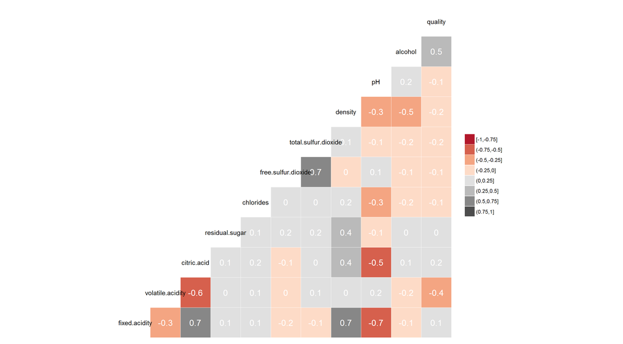

```
##
##  Pearson's product-moment correlation
##
## data:  wine$alcohol and wine$quality
## t = 21.639, df = 1597, p-value < 2.2e-16
## alternative hypothesis: true correlation is not equal to 0
## 95 percent confidence interval:
##  0.4373540 0.5132081
## sample estimates:
##       cor
## 0.4761663
```

```
##
##  Pearson's product-moment correlation
##
## data:  wine$volatile.acidity and wine$quality
## t = -16.954, df = 1597, p-value < 2.2e-16
## alternative hypothesis: true correlation is not equal to 0
## 95 percent confidence interval:
##  -0.4313210 -0.3482032
## sample estimates:
##        cor
## -0.3905578
```

The wine quality independent variable has strongest positive and negative pearson score with alcohol and volatile acidity respectively.

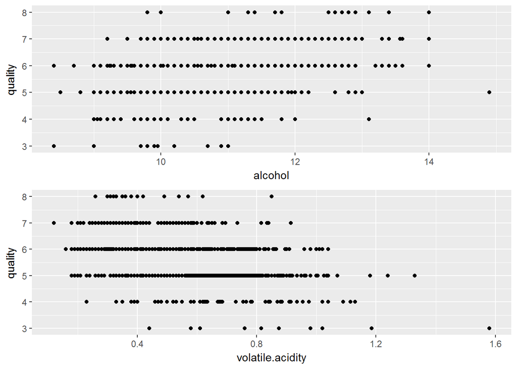

Despite the fact that quality has integer values we can barely make out the positive and negative slope by the fact that as alcohol increases there are more higher rated wines, and as volatile acidity increases there are more lower quality wines.

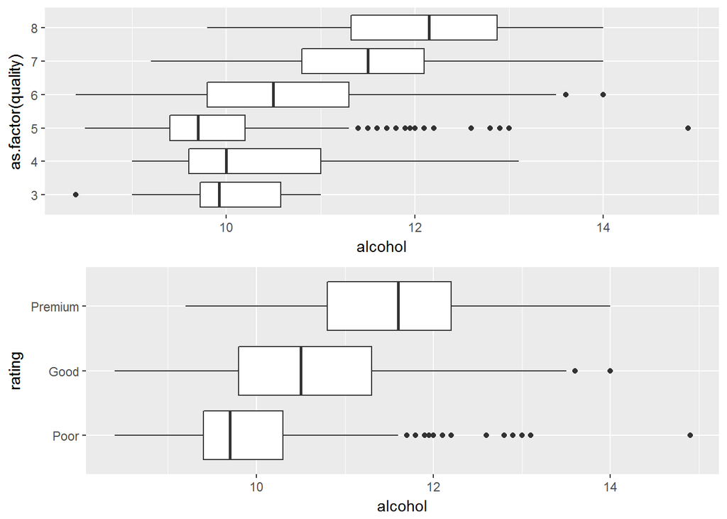

```
## wine$rating: Poor
##    Min. 1st Qu.  Median    Mean 3rd Qu.    Max.
##   8.400   9.400   9.700   9.926  10.300  14.900
## --------------------------------------------------------
## wine$rating: Good
##    Min. 1st Qu.  Median    Mean 3rd Qu.    Max.
##    8.40    9.80   10.50   10.63   11.30   14.00
## --------------------------------------------------------
## wine$rating: Premium
##    Min. 1st Qu.  Median    Mean 3rd Qu.    Max.
##    9.20   10.80   11.60   11.52   12.20   14.00
```

Using a box plot the trends are easier to observe when making quality into a categorical variable. The box plot supports the observation that as alcohol increases so to does quality score.

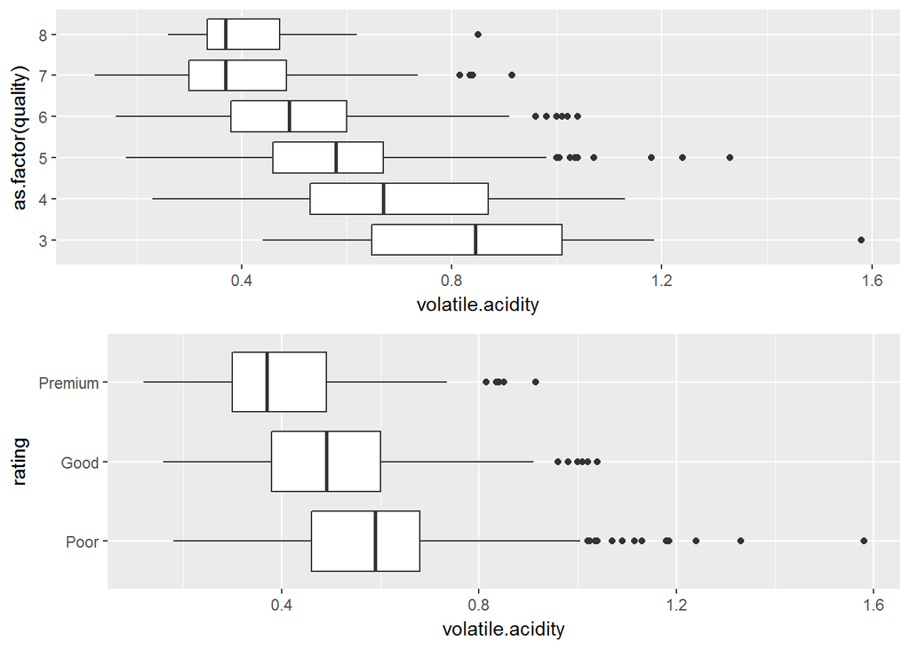

```
## wine$rating: Poor
##    Min. 1st Qu.  Median    Mean 3rd Qu.    Max.
##  0.1800  0.4600  0.5900  0.5895  0.6800  1.5800
## --------------------------------------------------------
## wine$rating: Good
##    Min. 1st Qu.  Median    Mean 3rd Qu.    Max.
##  0.1600  0.3800  0.4900  0.4975  0.6000  1.0400
## --------------------------------------------------------
## wine$rating: Premium
##    Min. 1st Qu.  Median    Mean 3rd Qu.    Max.
##  0.1200  0.3000  0.3700  0.4055  0.4900  0.9150
```

A similar observation can be made with volatile acidity but instead the medians of the higher rated groups are lower, indicating a negative relationship.

```
## [1] "fixed.acidity"    "volatile.acidity" "citric.acid"
## [4] "density"          "pH"               "alcohol"
## [7] "rating"
```

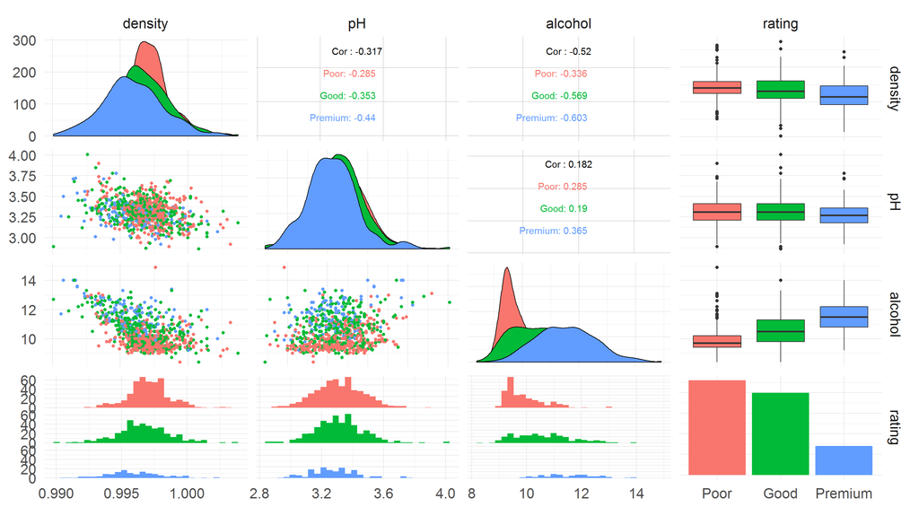

The scatter and density plots I will go over in more detail in the multivariate portion of the analysis.

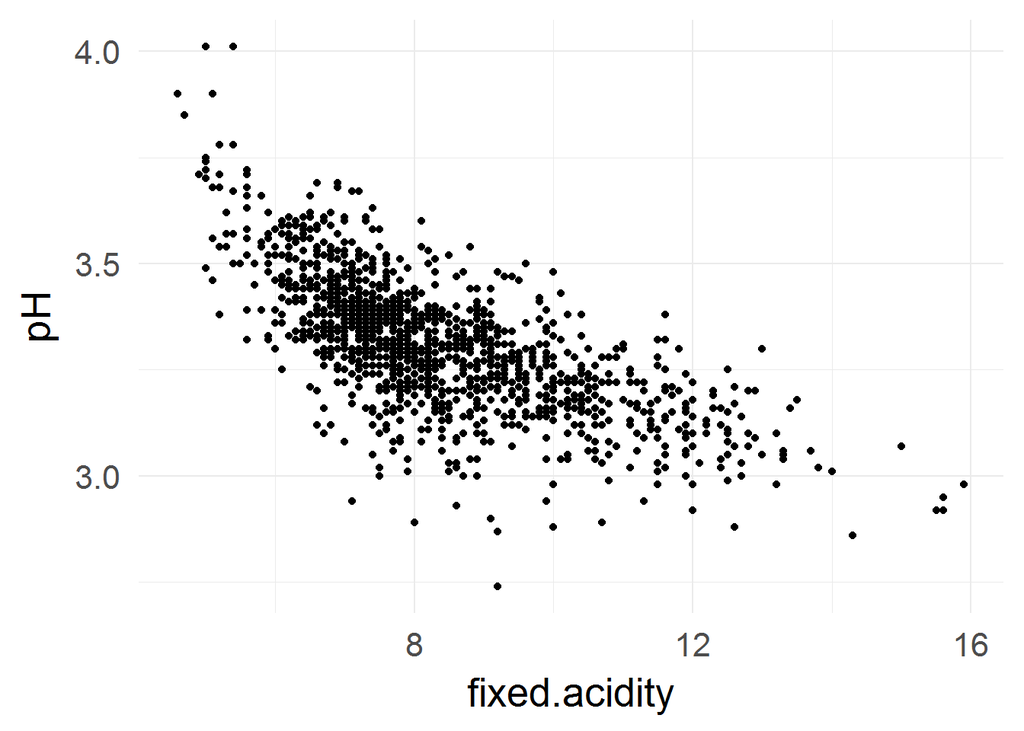

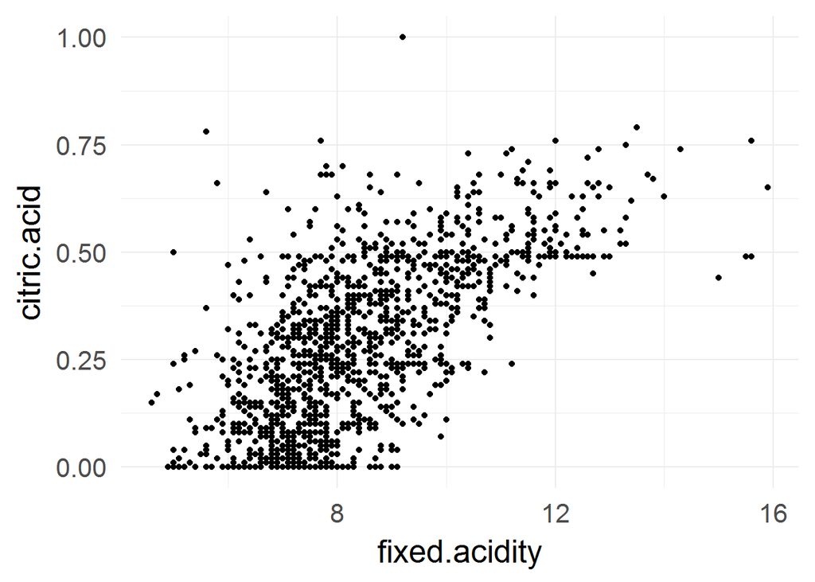

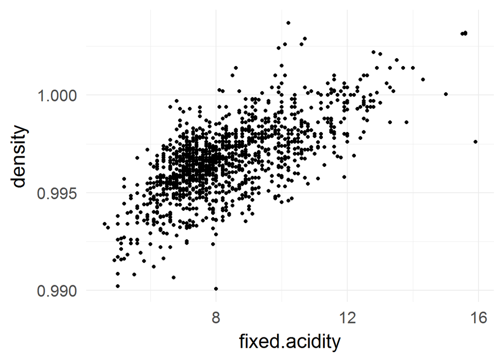

The strongest correlation found was between fixed acidity and PH. This is an obvious one because pH is a scale used to acidity. In this case the more tartaric acid in the wine the lower pH it has. I expect to see similar results for the other acids (volatile acidty, citric acid).

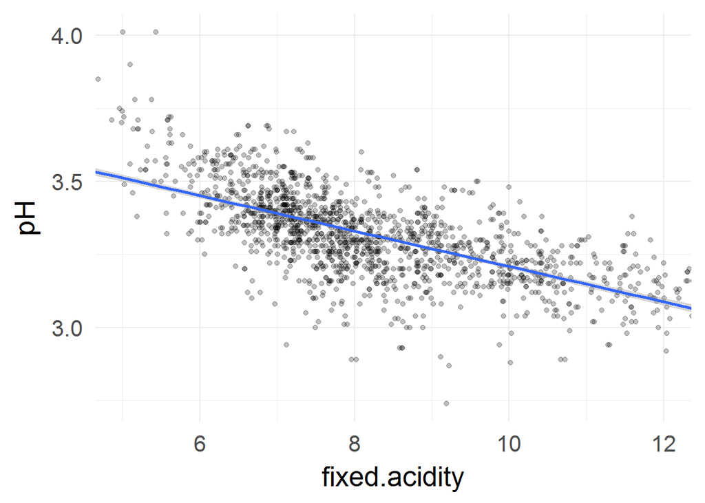

Using jitter and alpha we can remedy the problem of overplotting.

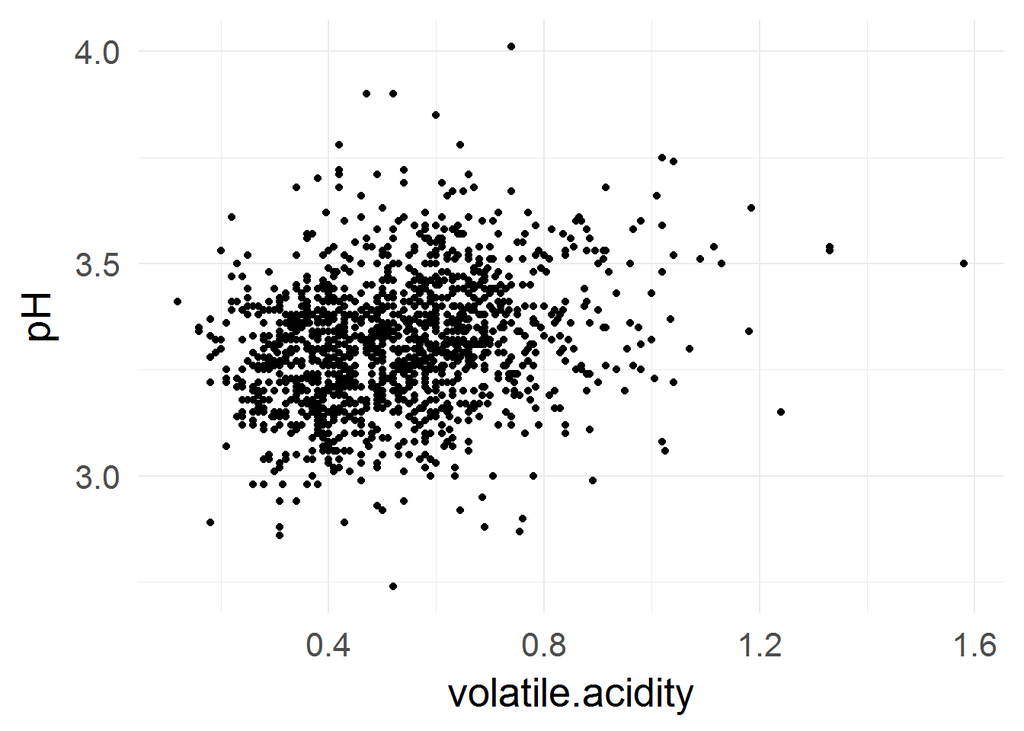

```
## [1] 0.2349373
```

The pearson score and visualization in the above suggests a weaker linear relationship. More volatile acidity could decrease the acidity.

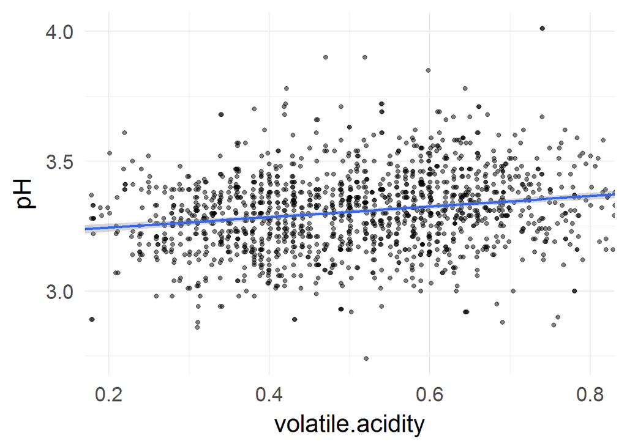

Using jitter and alpha transparency and zooming settings in we can make out where most of the points are falling, and make out a trend.

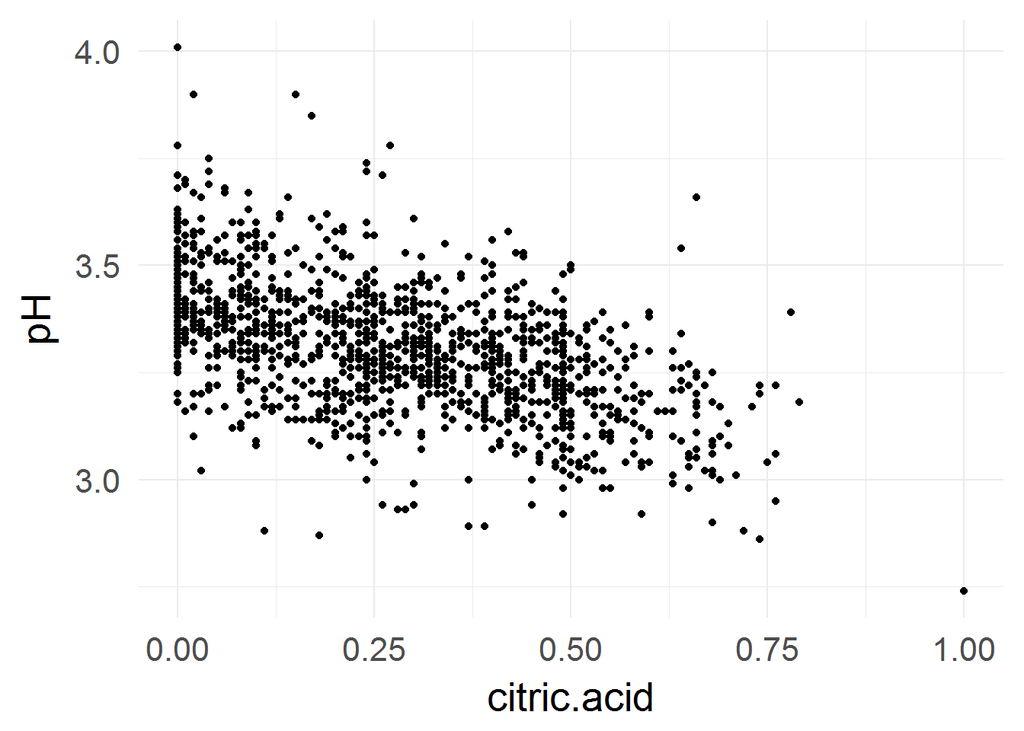

```
## [1] -0.5419041
```

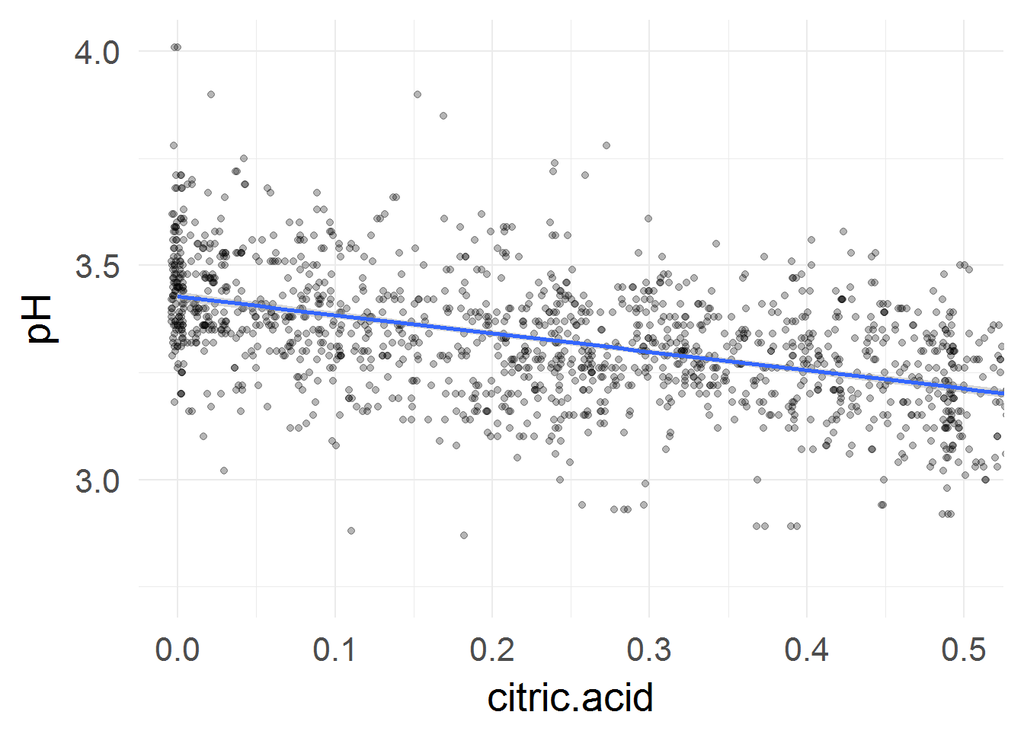

Applying the jitter and alpha transperancy I can see three clusters where the data points are heavily concentrated in. There is also a vertical band on the left indicating wines with 0 citric acid have varying pH values.

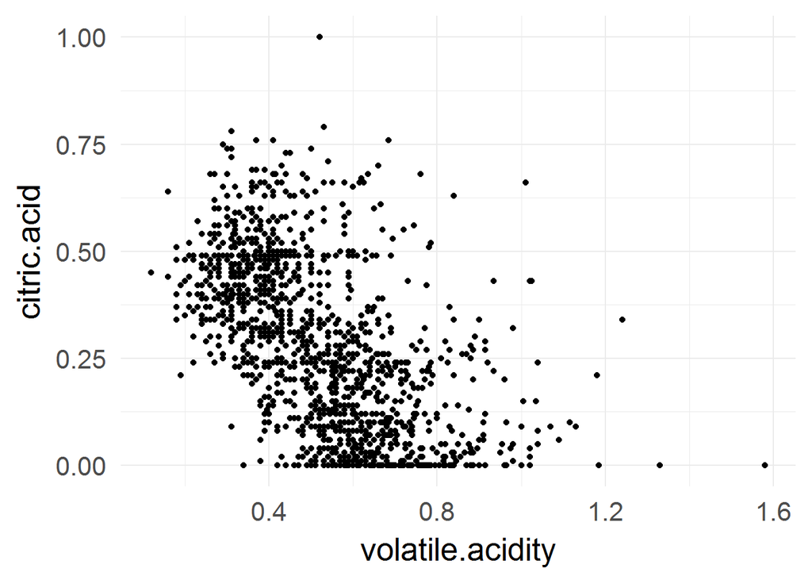

```
## [1] -0.5524957
```

Another strong correlation was between volatile acidity and citric acid. It is interesting to note that if fixed acidity tends to increase citric acid and if volatile acidity decreases citric acid this could be the same as saying that fixed acidity improves the “freshness” of the wine, while too much volatile acidity tends to decrease it.

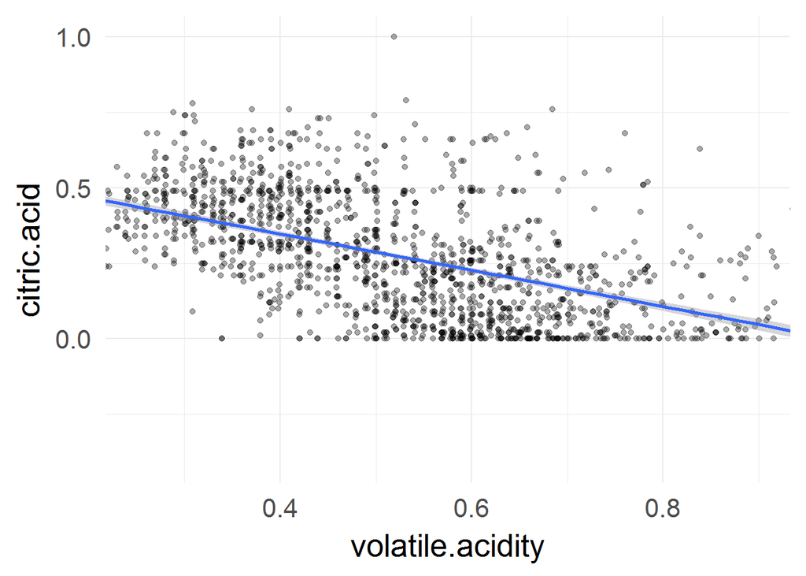

The visualization does appear to show a vague downward slope as volatile acidity increases.

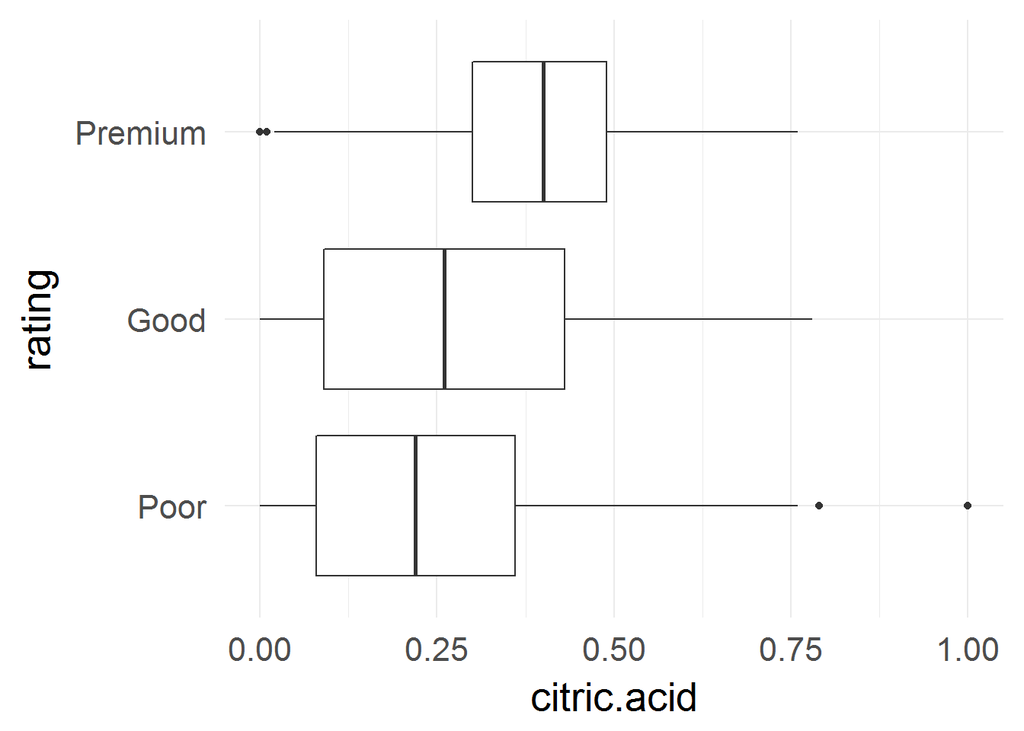

More citric acid seems to be an important aspect to premium wines with a clear trend for higher ratings having more of it.

```
## [1] 0.1240516
```